# P8105_HW3_hb2699

Han Bao

2022-10-15

```r
library(tidyverse)
library(readr)
```

```r
# install.packages("devtools")
devtools::install_github("p8105/p8105.datasets")
```

#Question 2

```r
# tidy the dataset
accel<- read_csv(file = "./accel_data.csv") %>%
  janitor::clean_names() %>%
  pivot_longer(
    activity_1:activity_1440,
    names_to = "minute",
    values_to = "activity",
    names_prefix = "activity_",
  ) %>%
  mutate(
    day_of_week = recode(day,
                         "Monday" = "Weekday",
                         "Tuesday" = "Weekday",
                         "Wednesday" = "Weekday",
                         "Thursday" = "Weekday",
                         "Friday" = "Weekday",
                         "Saturday" = "Weekend",
                         "Sunday" = "Weekend"))
nrow(accel)
```

```
## [1] 50400
```

```r
ncol(accel)
```

```
## [1] 6
```

The dataset contains 50400 rows and 6 columns.

```r
#aggregate the dataset across with minutes
accel %>%
  group_by(week,day) %>%
  summarize(total_activity=sum(activity)) %>%
  knitr::kable(
    caption = "Total activity across minutes")
```

Total activity across minutes

| week | day | total_activity |
| --- | --- | --- |
| 1 | Friday | 480542.62 |
| 1 | Monday | 78828.07 |
| 1 | Saturday | 376254.00 |
| 1 | Sunday | 631105.00 |
| 1 | Thursday | 355923.64 |
| 1 | Tuesday | 307094.24 |
| 1 | Wednesday | 340115.01 |
| 2 | Friday | 568839.00 |
| 2 | Monday | 295431.00 |
| 2 | Saturday | 607175.00 |
| 2 | Sunday | 422018.00 |
| 2 | Thursday | 474048.00 |
| 2 | Tuesday | 423245.00 |
| 2 | Wednesday | 440962.00 |
| 3 | Friday | 467420.00 |
| 3 | Monday | 685910.00 |
| 3 | Saturday | 382928.00 |
| 3 | Sunday | 467052.00 |
| 3 | Thursday | 371230.00 |
| 3 | Tuesday | 381507.00 |
| 3 | Wednesday | 468869.00 |
| 4 | Friday | 154049.00 |
| 4 | Monday | 409450.00 |
| 4 | Saturday | 1440.00 |
| 4 | Sunday | 260617.00 |
| 4 | Thursday | 340291.00 |
| 4 | Tuesday | 319568.00 |
| 4 | Wednesday | 434460.00 |
| 5 | Friday | 620860.00 |
| 5 | Monday | 389080.00 |
| 5 | Saturday | 1440.00 |
| 5 | Sunday | 138421.00 |
| 5 | Thursday | 549658.00 |
| 5 | Tuesday | 367824.00 |
| 5 | Wednesday | 445366.00 |

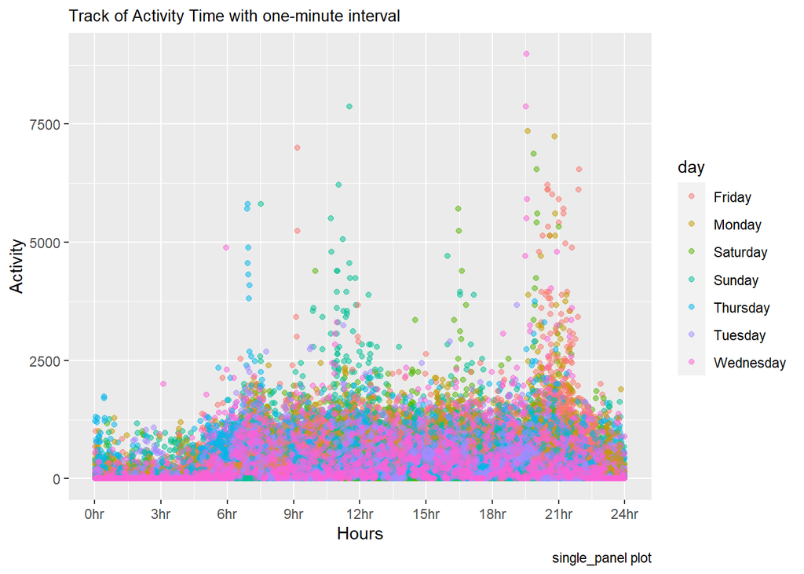

```r
accel %>%
  group_by(minute,day) %>%
  mutate(minute =as.numeric(minute)) %>%
  ggplot(aes(x = minute/60, y = activity)) +
  geom_point(aes(color = day), alpha = .5) +
   scale_x_continuous(
    breaks = c(0, 3, 6, 9, 12, 15, 18, 21, 24),
    labels = c("0hr", "3hr", "6hr", "9hr", "12hr", "15hr", "18hr", "21hr", "24hr")) +
  labs(
    title = "Track of Activity Time with one-minute interval",
    x = "Hours",
    y = "Activity",
    caption = "single_panel plot")+
  theme(plot.title = element_text(size=10))
```

```r
#git push -f
```

From the graph we can see that the most active period of time for the 63-year-old male is between 6am and 12pm and between 15pm and 22pm. The other times during night are lack of activity because he is sleeping and the two hours lack of activity after noon may be because he’s tired after the lunch. Besides, he is more active at night in weekdays than in weekends.

#Question 3

```r
# install.packages("devtools")
devtools::install_github("p8105/p8105.datasets",force = TRUE)
library(p8105.datasets)
data("ny_noaa")
```

```r
# clean and reform the dataset
ny_noaa = ny_noaa %>%
    janitor::clean_names()%>%
    mutate(ny_noaa, data = as.Date(date)) %>%
    mutate(year = as.integer(format(date, format = "%Y")),
         month = as.integer(format(date, format = "%m")),
         day = as.integer(format(date, format = "%d"))) %>%
    mutate(ny_noaa,tmax = as.numeric(tmax)/10) %>%
    mutate(ny_noaa,prcp = as.numeric(prcp)/10 ) %>%
    mutate(ny_noaa,tmin = as.numeric(tmin)/10 )
```

```r
#Find the most common value
ny_noaa %>%
  group_by(snow) %>%
  distinct() %>%
  summarize(freq = n()) %>%
  arrange(desc(freq)) %>%
  filter(!snow== 0) %>%
  head(1) %>%
  knitr::kable()
```

| snow | freq |
| --- | --- |
| 25 | 31022 |

[figure not shown]

```r
#Make a two-panel plot showing the average max temperature in January and in July in each station across years.
#label <- c('01'='January', '07'='July')
 ny_noaa %>%
   filter(month == 1| month == 7) %>%
   mutate(month = month.abb[month]) %>%
   filter(!is.na(tmax)) %>%
   mutate(tmax = as.numeric(tmax)) %>%
   group_by(month,year,id) %>%
   summarise(mean_month = mean(tmax)) %>%
   ggplot(aes(
     x=factor(year),
     y=mean_month,
     color=year))+
   geom_point() +
  facet_grid(.~month)+
  ggtitle('The mean max temperature in January and July in each station across years')+
  theme(axis.text.x = element_text(angle = 90, hjust = 1))
```

[figure not shown]

```r
#tmax vs tmin for the full dataset
ny_noaa %>%
  filter(!is.na(tmax),!is.na(tmin)) %>%
  mutate(tmax_2 = as.numeric(tmax, na.rm = TRUE)) %>%
  mutate(tmin_2 = as.numeric(tmin, na.rm = TRUE)) %>%
  ggplot(aes(x=tmax,y=tmin))+
  geom_hex()+
  ggtitle('tmax vs tmin for the full dataset')+
  theme(legend.position = "bottom")
```

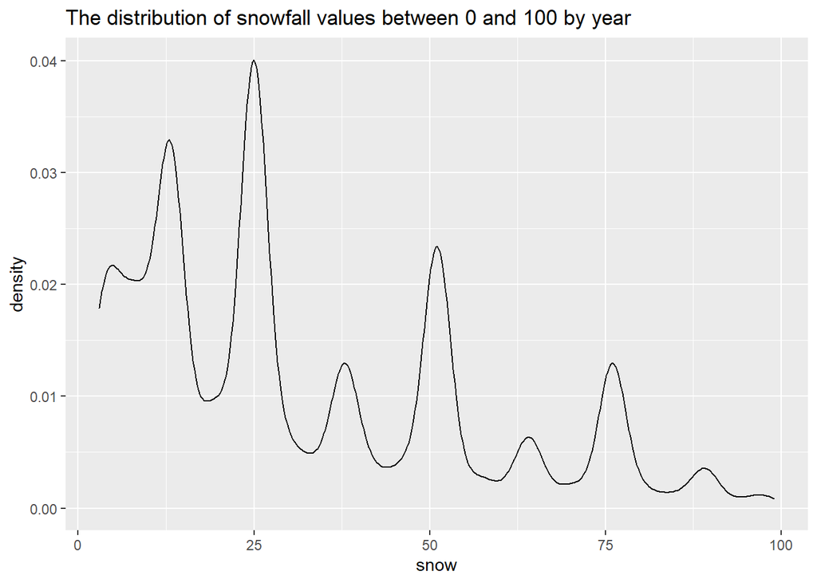

```r
#make a plot showing the distribution of snowfall values greater than 0 and less than 100 separately by year.
ny_noaa %>%
  filter(!is.na(snow)) %>%
  filter(snow>0,snow<100) %>%
  ggplot(aes(x=snow, color=year))+
  geom_density( alpha=0.3)+
  ggtitle('The distribution of snowfall values between 0 and 100 by year')+
  theme(legend.position = "bottom")
```